# SME0809 - Inferência Bayesiana

#### Nome: Juan Lucas Montanaro

## Exercício 2 - Resposta

Primeiramente, o exercício é dividido em duas situações, a primeira com apenas uma medição da variável de interesse e a segunda com 100 medições, assim, visto que a primeira situação já foi feita em aula, vou continuar e resolver apenas a segunda situação.

Então, do enunciado tem-se que cada físico modelou a distribuição *a priori* para $\mu$ como:

- $\mu$~$N(900, 20^2)$, para o físico A; e
- $\mu$~$N(900, 80^2)$, para o físico B.

### a) Faça um esboço do gráfico das distribuições *a priori* dos dois físicos.

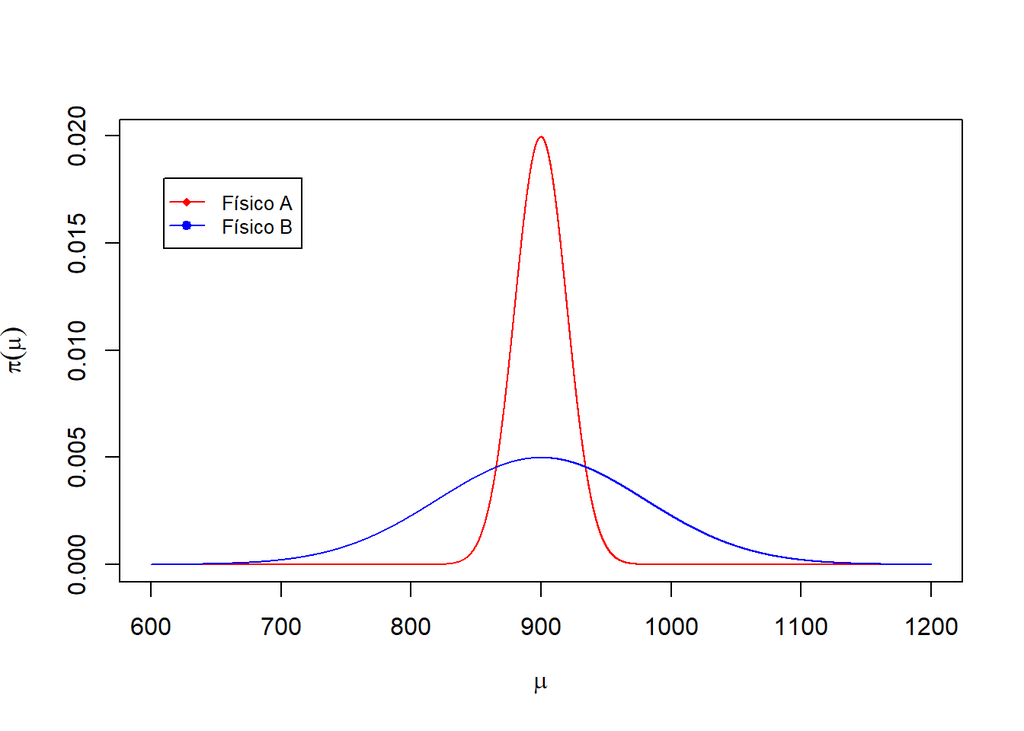

### b) Encontre a distribuição *a posteriori* para o físico A e para o físico B.

Em primeiro lugar, para atualizar a informação sobre a incerteza em relação a $\mu$, é necessário encontrar a função de verossimilhança, $L(\mu|y)$. Assim, como Y ~ $N(\mu, 40^2)$ e foi coletada uma amostra aleatória de Y de tamanho n, então:

$$L(\mu|y) = \prod_{i=1}^n \frac{
\exp(\frac{-1}{2.40^2}(y_i-\mu)^2) } { (2\pi.40)^\frac{-1}{2} } \propto
\exp\Big(\frac{-1}{2.40^2}\sum_{i=1}^n(y_i-\mu)^2\Big)$$

E desenvolvendo $\sum_{i=1}^n(y_i-\mu)^2$, a expressão se resume em:

$$L(\mu|y) \propto
\exp(-\frac{n}{2.40^2}(\mu-\overline{y})^2)$$

Desse modo, como $\mu$ ~ $N(900, \sigma_0^2)$ (sendo $\sigma_0=20$ para o físico A e $\sigma_0=80$ para o físico B), a distribuição *a posteriori* é da forma:

$$\pi(\mu|y) \propto L(\mu|y) .\pi(\mu)
\propto \\ \propto \exp\Big( -\frac{n}{2.40^2}(\mu-\overline{y})^2
\Big). \exp\Big( \frac{-1}{2\sigma_0^2}(\mu-900)^2 \Big) \propto
\\ \propto \exp\Bigg( -\frac{n}{2.40^2}(\mu-\overline{y})^2 -
\frac{1}{2\sigma_0^2}(\mu-900)^2 \Bigg)$$

E, como visto em aula, esta expressão pode ser escrita como:

$$\pi(\mu|y) \propto \exp(-\frac{1}{2}
\bigg[\frac{n}{40^2}+\frac{1}{\sigma_0^2}\bigg] (\mu-c)^2)$$

Em que $c = \frac{1}{\frac{n}{40^2}+\frac{1}{\sigma_0^2}}\bigg(\frac{n.\overline{y}}{40^2}+\frac{900}{\sigma_0^2}\bigg)$. Portanto, $\mu|y$ ~ $N\Bigg(c, \frac{1}{\frac{n}{40^2}+\frac{1}{\sigma_0^2}}\Bigg)$.

### c) Faça um esboço do gráfico das distribuições: *a priori* e *a posteriori* de cada um dos dois físicos.

Dadas as 100 medições de Y, temos que:

```r
# Dados:
y <- c(921.3429, 910.8055, 879.7302, 899.3456, 837.7587,
       880.95, 830.4974, 856.1041, 777.5677, 983.3444,
       981.048, 863.2836, 943.1702, 904.5064, 831.879,
       854.2947, 920.2139, 839.7896, 897.0014, 839.3796,
       872.4004, 884.6379, 892.7966, 897.9938, 840.228,
       823.2803, 903.4257, 798.5764, 862.5581, 938.8837,
       894.951, 871.0477, 863.9725, 857.6077, 856.3452,
       906.6818, 859.7368, 876.7236, 868.8648, 900.386,
       839.8117, 878.5936, 866.6935, 921.2941, 877.8528,
       897.6217, 894.6499, 830.6403, 935.6717, 948.9588,
       888.0726, 788.6694, 877.4076, 863.1756, 982.6952,
       934.724, 898.8038, 874.8416, 905.8379, 843.0447,
       877.0727, 894.5569, 959.8427, 826.6365, 907.9904,
       912.9051, 912.4662, 975.3224, 922.8291, 934.6569,
       953.236, 833.5084, 842.0623, 885.3881, 918.0987,
       842.0927, 875.6968, 826.3312, 870.4634, 866.2226,
       845.4767, 914.2475, 922.4006, 832.359, 877.5627,
       887.8087, 879.4061, 925.3103, 877.6632, 877.3689,
       854.1189, 904.5891, 882.893, 866.3494, 892.4554,
       908.3249, 873.6439, 914.1283, 879.8893, 843.1085
       )
sigma.dados <- 40
n <- length(y)
```

Veja o gráfico comparativo:

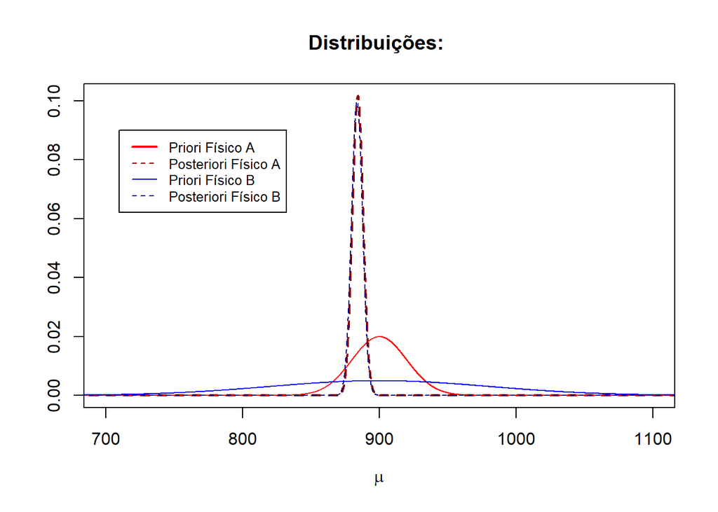

### d) Observando o gráfico, qual físico aprendeu mais com o experimento. Justifique.

**R.:** A partir do gráfico, quem mais aprendeu após observar os dados foi o físico B, pois seu primeiro modelo propunha que os possíveis valores do parâmetro estariam dispersos em um intervalo maior do que o do físico A, que propunha uma concentração maior dos dados. De fato, a linha azul do gráfico não apresenta uma concentração, ela cobre uma área grande em torno de $\mu = 900$ , diferente da linha azul escura, que concentra os dados em torno de $\mu =$ 883.727. E o modelo do outro físico propunha uma concentração maior dos dados (a linha vermelha apresente um pico em $\mu = 900$). Logo, quem mais aprendeu foi o físico B.

### e) Construa uma tabela que contenha o resumo *a priori* e o resumo *a posteriori*.

Considere “IC95” como o intervalo de credibilidade 95% para o parâmetro, sendo “IC95.inf” e “IC95.sup” os limites inferior e superior, respectivamente. Então, este é o resumo para o físico A:

[output not shown]

E este é o resumo para o físico B:

[output not shown]

### f) Encontre as distribuições preditivas e faça um esboço de seus gráficos.

**R.:** Segundo Ricardo Ehlers (página 14), neste caso, para encontrar as distribuições preditivas podemos usar o fato de que Y pode ser fatorado da seguinte forma: $Y = \mu + \epsilon$, em que $\epsilon$ ~ N(0, $40^2$); e $\mu = m + w$, em que $w$ ~ N(0, $\sigma^2$), $m = E(\mu)$ e $\sigma^2 = Var(\mu)$.

Dessa forma, Cov($\mu, \epsilon$) = Cov($m, w$) = 0, o que implica independência para distribuições normais; portanto, Y é a soma de duas distribuições normais independentes, ou seja, Y ~ N($m$, $40^2+\sigma^2$).

Substituindo os valores de $m$ e $\sigma$ tanto para as distribuições preditivas *a priori* quanto para as *a posteriori*, obtemos que:

- para o físico A: $Y_{pri}$ ~ N(900, 44.721$^2$) e $Y_{post}$ ~ N(884.31, 40.192$^2$);
- para o físico B: $Y_{pri}$ ~ N(900, 89.443$^2$) e $Y_{post}$ ~ N(883.73, 40.199$^2$).

  Veja os gráficos:

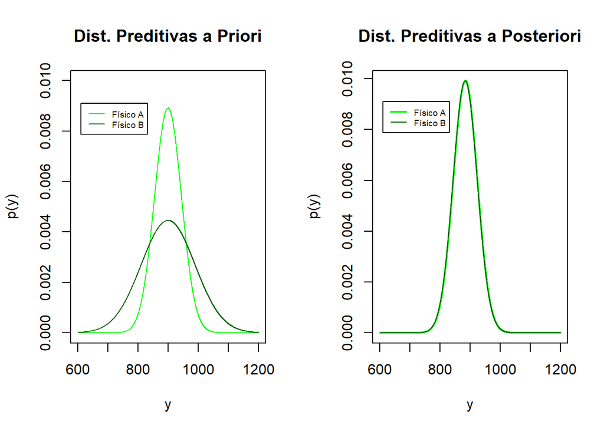